# capstone2

## Experimental Design

### Are there superficial characteristics about kickstarters that improve success?

This project is going to explore a kickstarter dataset in primarily two ways:

##### Does name length correlate with kickstarter success?

##### Are some categories of kickstarters more successful than others?

With some hints about these questions we can design an experiment that will verify if some categories statistically perform better than others or if some name lengths are statistically better for starting the kickstarter.

#### Setup

We will be using the standard pandas, matplotlib, seaborn, and other statistical tools to take a look at our data first. We drop 'ID' and other unnecessary columns from our dataframe.

```python
import pandas as pd
import matplotlib.pyplot as plt
import seaborn as sns
import numpy as np
from scipy import stats
# sns.set_style('dark')
plt.style.use('ggplot')
%matplotlib inline

kick1 = pd.read_csv('../../../kickstarter_set/ks-projects-201801.csv')
kick1.drop(columns=['ID', 'goal', 'currency', 'pledged'], inplace=True)
kick1.loc[:,['deadline', 'launched']] = kick1[['deadline', 'launched']].apply(pd.to_datetime)
kick1.head(3)
```

|  | name | category | main_category | deadline | launched | state | backers | country | usd pledged | usd_pledged_real | usd_goal_real |
| --- | --- | --- | --- | --- | --- | --- | --- | --- | --- | --- | --- |
| 0 | The Songs of Adelaide & Abullah | Poetry | Publishing | 2015-10-09 | 2015-08-11 12:12:28 | failed | 0 | GB | 0.0 | 0.0 | 1533.95 |
| 1 | Greeting From Earth: ZGAC Arts Capsule For ET | Narrative Film | Film & Video | 2017-11-01 | 2017-09-02 04:43:57 | failed | 15 | US | 100.0 | 2421.0 | 30000.00 |
| 2 | Where is Hank? | Narrative Film | Film & Video | 2013-02-26 | 2013-01-12 00:20:50 | failed | 3 | US | 220.0 | 220.0 | 45000.00 |

```python
kick1.info(), kick1.describe()
```

```
<class 'pandas.core.frame.DataFrame'>
RangeIndex: 378661 entries, 0 to 378660
Data columns (total 11 columns):
name                378657 non-null object
category            378661 non-null object
main_category       378661 non-null object
deadline            378661 non-null datetime64[ns]
launched            378661 non-null datetime64[ns]
state               378661 non-null object
backers             378661 non-null int64
country             378661 non-null object
usd pledged         374864 non-null float64
usd_pledged_real    378661 non-null float64
usd_goal_real       378661 non-null float64
dtypes: datetime64[ns](2), float64(3), int64(1), object(5)
memory usage: 31.8+ MB
```

```
(None,              backers   usd pledged  usd_pledged_real  usd_goal_real
 count  378661.000000  3.748640e+05      3.786610e+05   3.786610e+05
 mean      105.617476  7.036729e+03      9.058924e+03   4.545440e+04
 std       907.185035  7.863975e+04      9.097334e+04   1.152950e+06
 min         0.000000  0.000000e+00      0.000000e+00   1.000000e-02
 25%         2.000000  1.698000e+01      3.100000e+01   2.000000e+03
 50%        12.000000  3.947200e+02      6.243300e+02   5.500000e+03
 75%        56.000000  3.034090e+03      4.050000e+03   1.550000e+04
 max    219382.000000  2.033899e+07      2.033899e+07   1.663614e+08)
```

### Pairplot

The pairplot gives us a high-level view of the data. We can look for odd trends or other things that might stand out.

The plot shows an interesting cling to the axis across some values - I haven't exactly figured that out yet.

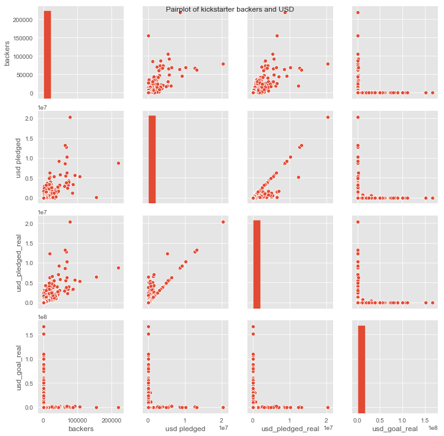

```python
pp = sns.pairplot(kick1)
pp.fig.suptitle('Pairplot of kickstarter backers and USD')
```

### Jointplot

This jointplot will give us an idea of all of the points with name length versus actual pledged value relationships. It does not appear that, other than outliers, there is much of a relationship here.

For the y axis, we are using actual pledged versus goal to indicate whether or not the kickstarter was successful and by what degree.

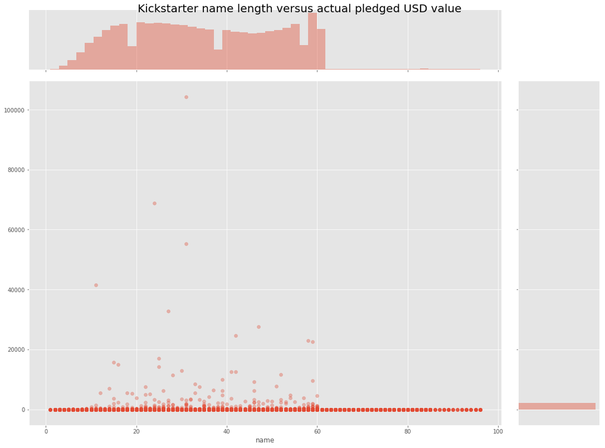

```python
joint = sns.jointplot(x=kick1.name.apply(lambda x: len(str(x))),
              y=(kick1['usd_pledged_real'] / kick1['usd_goal_real']), alpha=0.35)
joint.fig.set_figwidth(16)
joint.fig.set_figheight(12)
joint.fig.suptitle('Kickstarter name length versus actual pledged USD value', size=20)
```

### Verification

It turns out the pvalue is quite high, indicating any difference is due to random chance.

#### (Side note)

It is very interesting how dips in name lengths exist around multiples of 20. There could exist a price-point difference at these lengths.

```python
kick1['name_length'] = kick1.name.apply(lambda x: len(str(x)))
print((kick1['usd_pledged_real'] / kick1['usd_goal_real']).describe())
print('\nThe number of kickstarter names with less than or equal to 40 characters: {}'
      .format(len(kick1[kick1.name_length >= 40])))
stats.ttest_ind(kick1[kick1.name_length >= 40]['usd_pledged_real'],
                kick1[kick1.name_length >40]['usd_pledged_real'])
```

[output not shown]

```
Ttest_indResult(statistic=-0.30036626389271515, pvalue=0.7638980026223293)
```

### Boxplots across categories

Below we have boxplots of the ratios of actual pledged USD against USD goals by main category.

Once again, other than the outliers, it does not appear that some categories are significantly more successful than others. We can run another test to check the numbers.

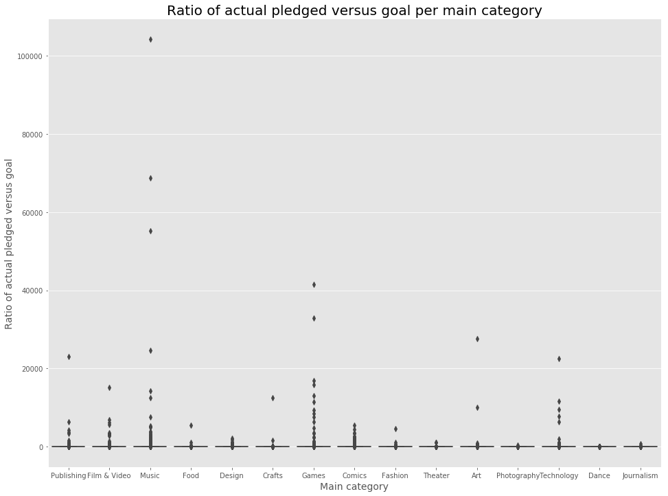

```python
fig, ax1 = plt.subplots(1, 1, figsize=(16,12))
sns.boxplot(data=kick1, x='main_category',
            y=kick1['usd_pledged_real'] / kick1['usd_goal_real'], ax=ax1)
ax1.set_title('Ratio of actual pledged versus goal per main category', size=20)
ax1.set_xlabel('Main category', size=14)
ax1.set_ylabel('Ratio of actual pledged versus goal', size=14)
```

```python
music1 = kick1[kick1.main_category == 'Music']
games1 = kick1[kick1.main_category == 'Games']
tech1 = kick1[kick1.main_category == 'Technology']

stats.f_oneway(music1['usd_pledged_real'] / music1['usd_goal_real'],
               games1['usd_pledged_real'] / games1['usd_goal_real'],
               tech1['usd_pledged_real'] / tech1['usd_goal_real'])
```

```
F_onewayResult(statistic=1.291171316081175, pvalue=0.2749523715887546)
```

To check three together that visually appear different, we will use an F-one way test - this can be interpreted very similarly to a t-test. We select 'Music', 'Games', and 'Technology' to verify. This also returns a p-value that indicates the differences are due to random chance.

#### Experimental design

I believe any experiment to further verify these results is tricky, as it requires an investment of long periods of time and effort, but let's tackle one of them - the performances of different categories.

#### Categorical performance test

We can assign five teams of our kickstarter employees two different categories of kickstarts each. The two will be quite unrelated as not to create overlap and association bias; for example, two separate kickstarts for one team in the games and food categories. This will help separate any variables associated with the successes, abilities, and networks of our employees and teams. Their game and food kickstarts will now have the same efforts, networks, and other skills shared.

The projects will also have the same USD goals, in the same city, and be advertised on the same platforms with the same funding for the same length of time, maybe about one month. If we can create nearly all things equal, we can determine how successful some categories are - *all things equal*.

*If successful,* statistical results will yield significant p-values between different segments below the threshold of 0.05. It is a small sample for a test, but when all things are equal across the kickstarters, we can be confident in our results. To improve this experiment, I would certainly recommend many more groups running the pairs of kickstarters, perhaps closer to 50 teams - but that might be overly burdensome.

### Further research proposal

Other questions linger for further research possibilities. Some of the questions that also came to mind are below:

Are there some words that are more successful than others?

Do kickstarter lengths have any association with success?

Do seasons, months, or maybe days of the week have anything to do with success metrics? - Small visual below...

```
F_onewayResult(statistic=2.5787107647204732, pvalue=0.07587670199391434)
```

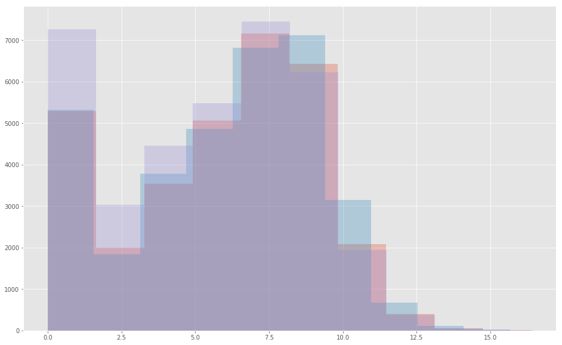

```python
june = kick1[kick1.deadline.dt.month == 6]['usd_pledged_real']
july = kick1[kick1.deadline.dt.month == 7]['usd_pledged_real']
august = kick1[kick1.deadline.dt.month == 8]['usd_pledged_real']
print(stats.f_oneway(june, july, august))
np.log(june.dropna() + 1).hist(alpha=0.3,figsize=(16,10))
np.log(july.dropna() + 1).hist(alpha=0.3)
np.log(august.dropna() + 1).hist(alpha=0.3)
```